# ggplot2の辞書

#### 1.4.3.2 フォント

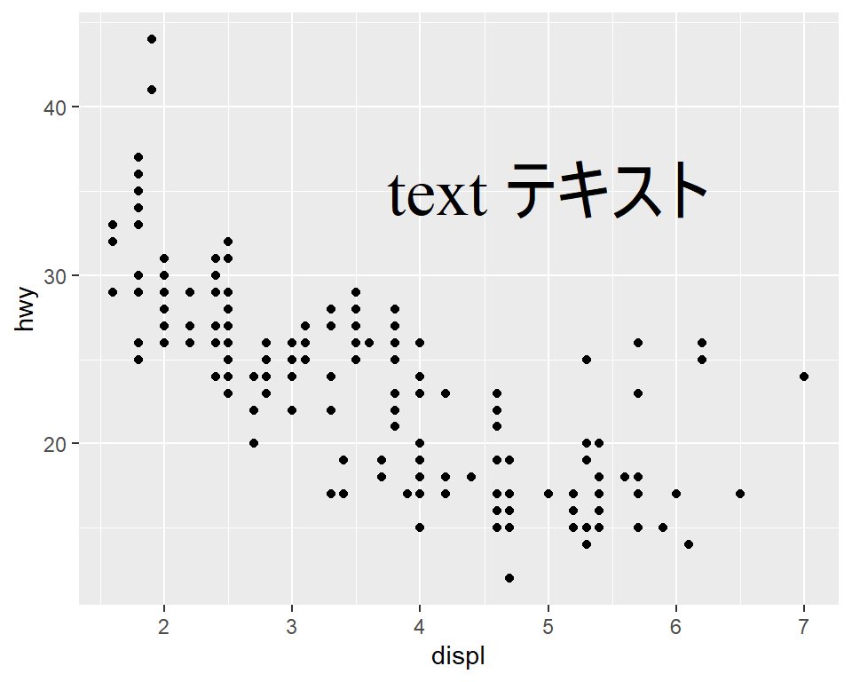

```r
p +
  geom_point() +
  annotate(geom = "text",
           x = 5, y = 35,  # テキストの中心座標位置
           label = "text テキスト",
           size = 10,
           family = "serif")
```

#### 1.4.3.3 相関係数を入れる

- 部分的にイタリックにする場合
  - rを`italic()`で囲む
  - `=`をテキスト内に表示する場合`==`と入れる
  - `parse = TRUE`を入れる

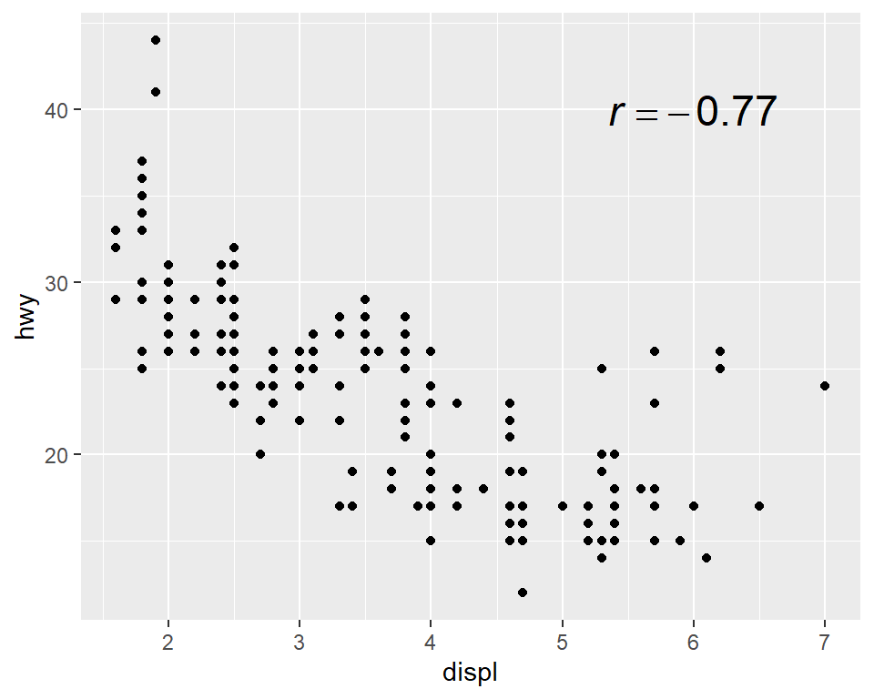

```r
# 相関係数の計算
corc <-
  cor(mpg$displ, mpg$hwy) %>%
  round(2)

p +
  geom_point() +
  annotate("text",
           label = str_c("italic(r) == ", corc), # 相関係数の代入
           parse = TRUE,
           x = 6, y = 40,
           size = 6)
```

## 1.5 グラフ外にテキストを追加

- `coord_cartesian(clip = "off")`を使って、グラフの灰色背景部分を`xlim =`,`ylim =`の座標で指定した領域までに表示制限する必要がある

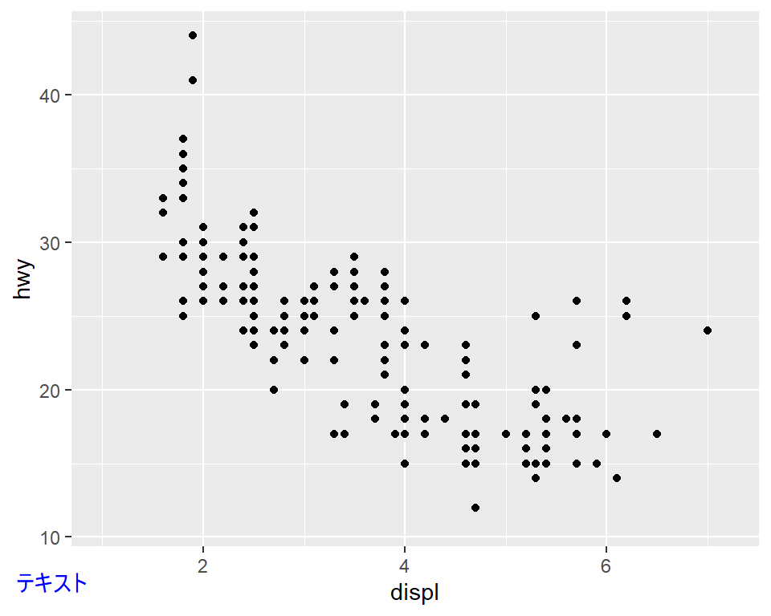

```r
p +
  geom_point() +
  annotate(geom = "text",
           x = 0.5, y = 7,  # テキストの中心座標位置
           color = "blue",
           sie = 10,
           label = "テキスト") +
  coord_cartesian(xlim = c(1, 7.2),
                  ylim = c(11, 44),
                  clip = "off")
```

## 1.6 グラフ内外の自由な位置にテキストや画像を追加

- パッケージ`cowplot`を使用
- x,yの値は、グラフ全体の範囲をそれぞれ0～1としている

### 1.6.1 テキスト

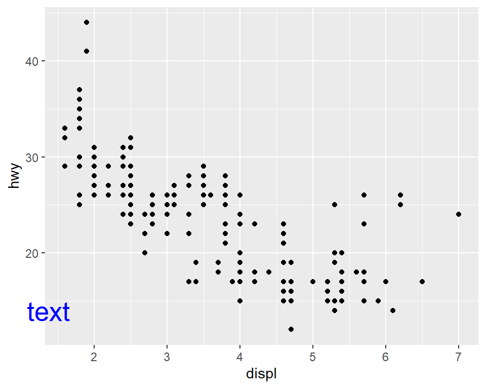

```r
library(cowplot)

ppc <-
p + geom_point()

ggdraw(ppc) +
  draw_label("text",
             colour = "blue",
             size = 20,
             x = 0.1,
             y = 0.2
)
```

### 1.6.2 画像

- `magick`パッケージのインストールが必要

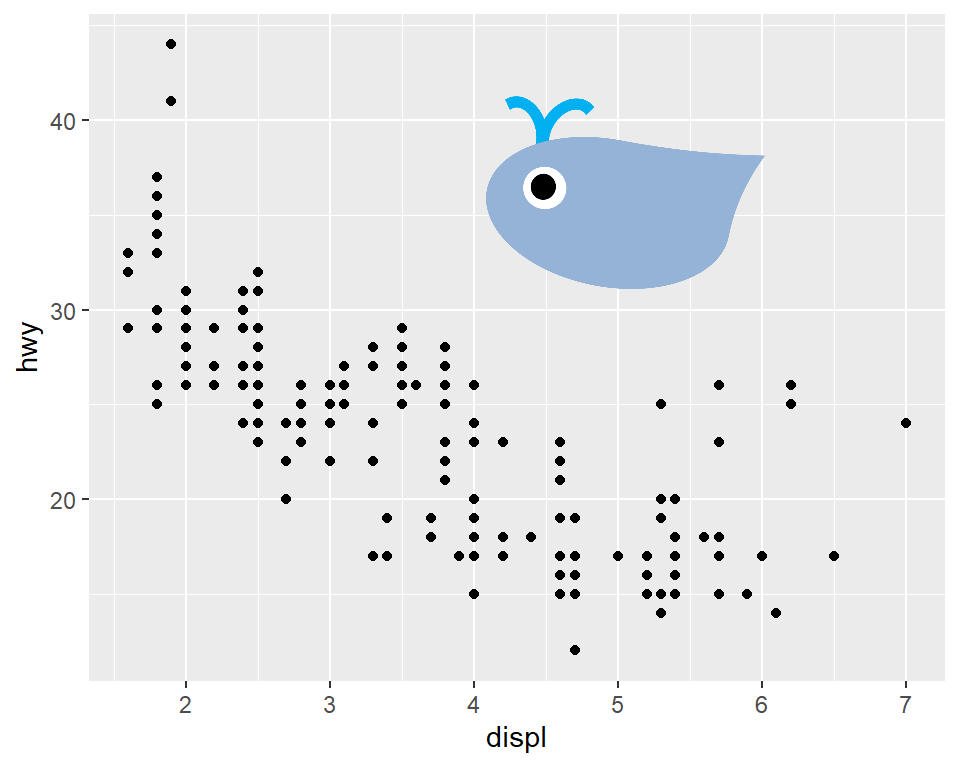

```r
ggdraw(ppc) +
  draw_image("image/kujira.png",
             x = 0.5, y = 0.6,
             width = 0.3, height = 0.3)
```

## 1.7 線のあてはめ

### 1.7.1 曲線

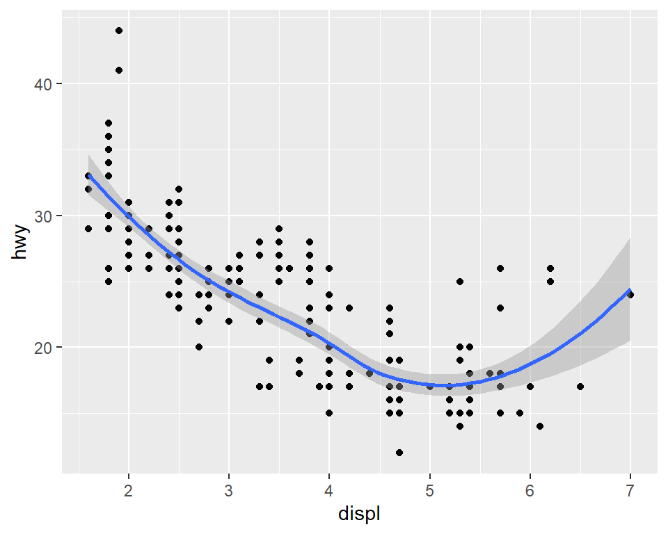

```r
p +
  geom_point() +
  geom_smooth()
```

### 1.7.2 直線

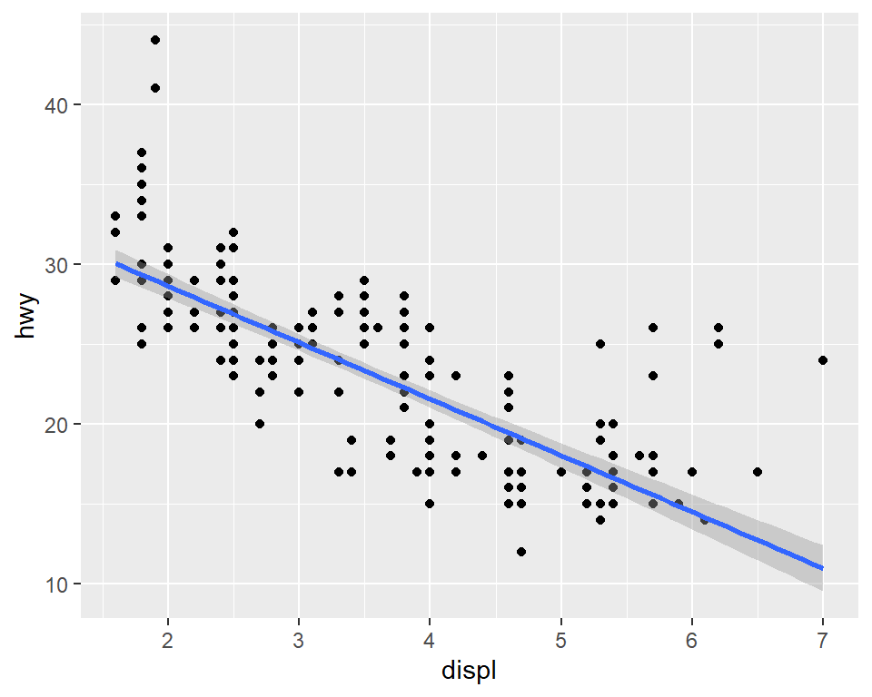

```r
p +
  geom_point() +
  geom_smooth(method = "lm")
```

#### 1.7.2.1 標準誤差の範囲を消す

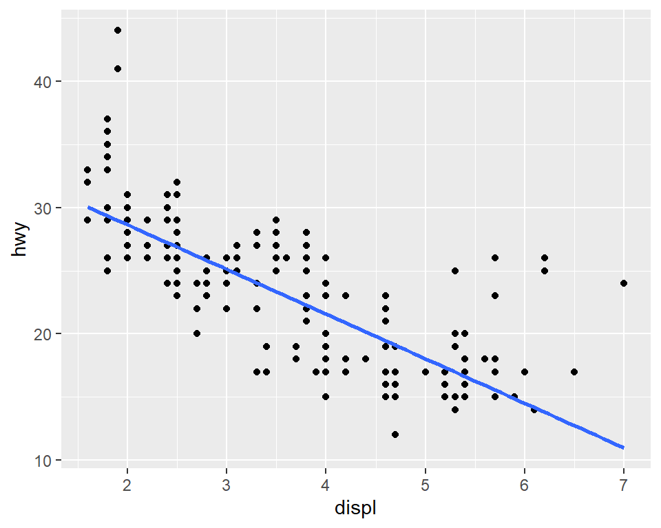

```r
p +
  geom_point() +
  geom_smooth(method = "lm", se = FALSE)
```

## 1.8 背景の色や線のテンプレート変更

### theme_bw

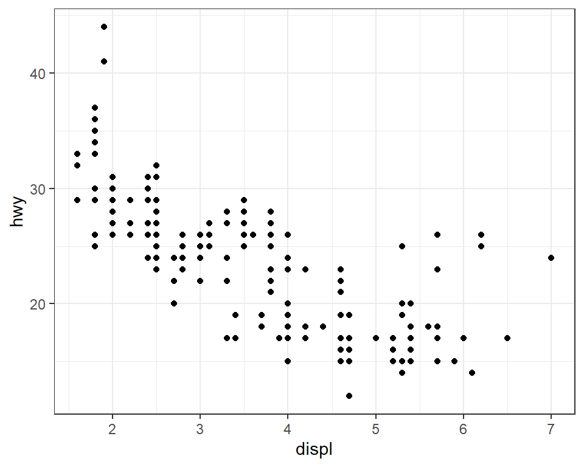

```r
p +
  geom_point() +
  theme_bw()
```

### theme_classic

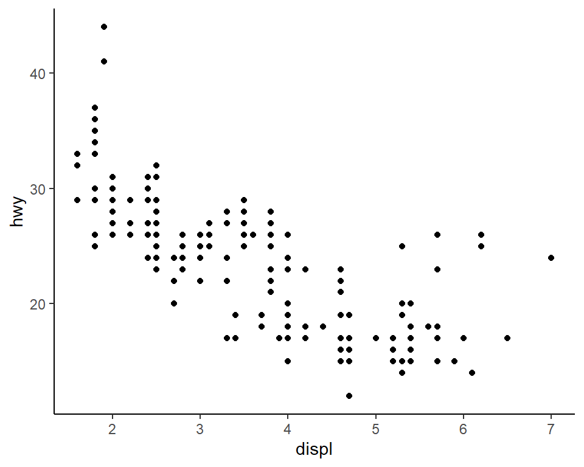

```r
p +
  geom_point() +
  theme_classic()
```

### theme_modern

- 全体的に見やすくなるテンプレート

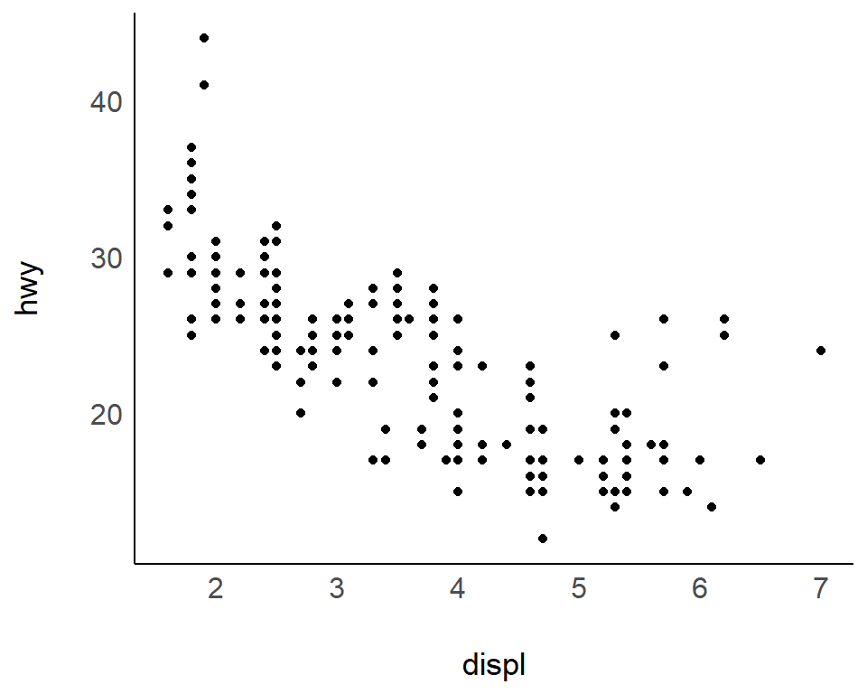

```r
library(see)

p +
  geom_point() +
  theme_modern()
```

## 1.9 ジッター入り

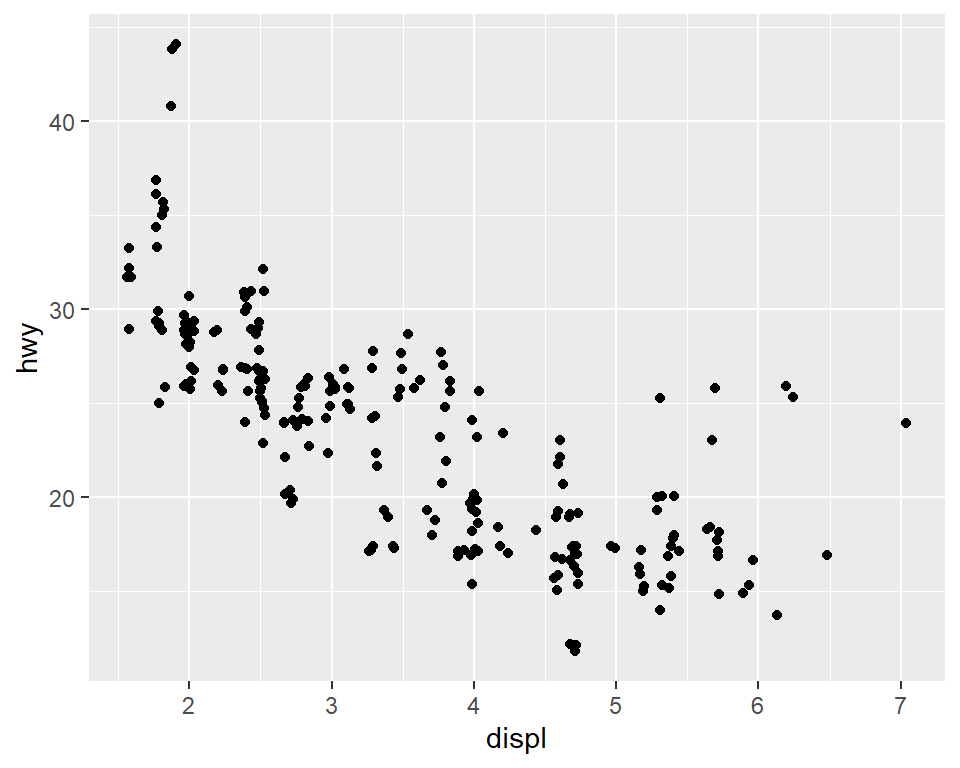

```r
p +
  geom_jitter()
```

### 1.9.1 ジッターの調整

#### 0.2 x 0.2

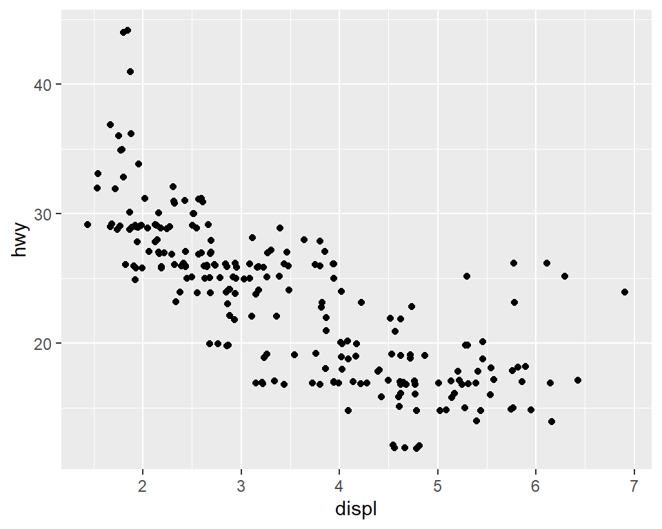

```r
p +
  geom_jitter(width = 0.2, height = 0.2)
```

#### 0.5 x 0.5

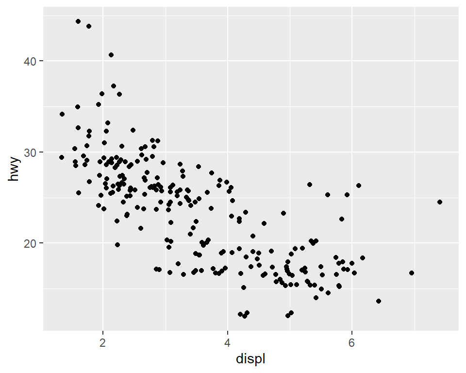

```r
p +
  geom_jitter(width = 0.5, height = 0.5)
```

#### 1 x 1

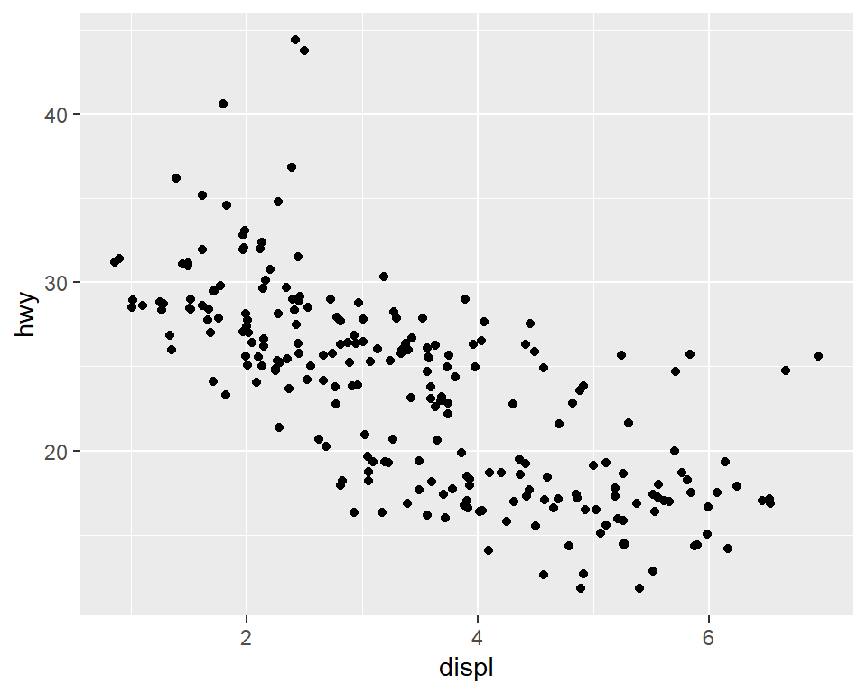

```r
p +
  geom_jitter(width = 1, height = 1)
```

#### 2 x 0.5

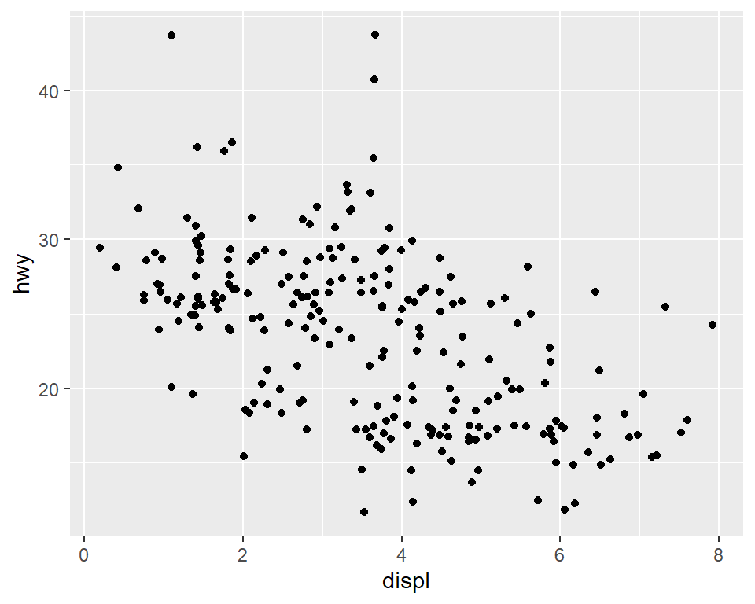

```r
p +
  geom_jitter(width = 2, height = 0.5)
```

#### 0.5 x 2

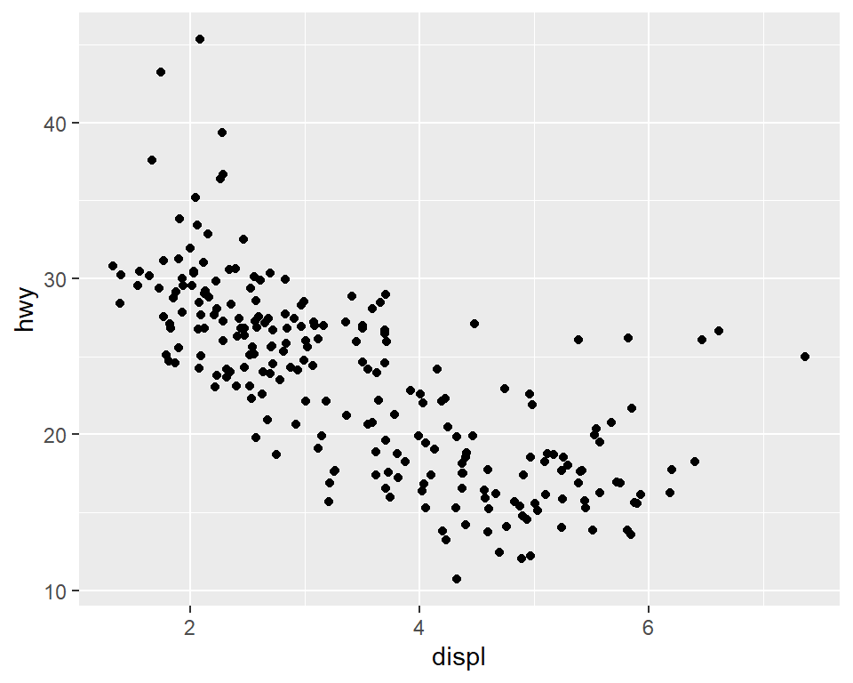

```r
p +
  geom_jitter(width = 0.5, height = 2)
```

## 1.10 データ数によって点の大きさを変える

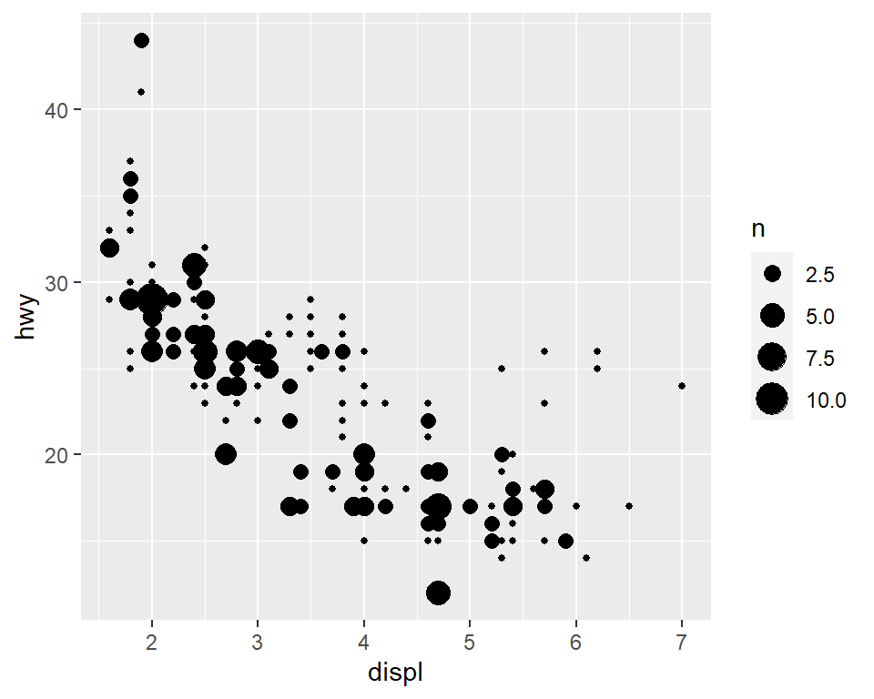

```r
p +
  geom_count()
```

# 2 散布図(2): 3変数以上

## 2.1 区分

### 2.1.1 色

- 使用変数の説明
  - `class`: 車種

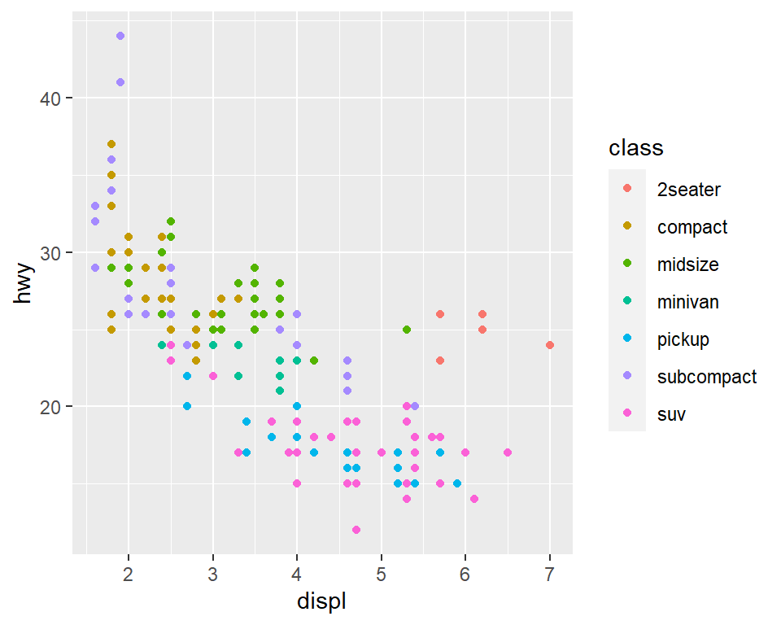

```r
pc <-
ggplot(mpg, aes(displ, hwy,
                color = class)) # 色分けに使用する変数指定

pc + geom_point()
```

#### 2.1.1.1 色を手動で指定

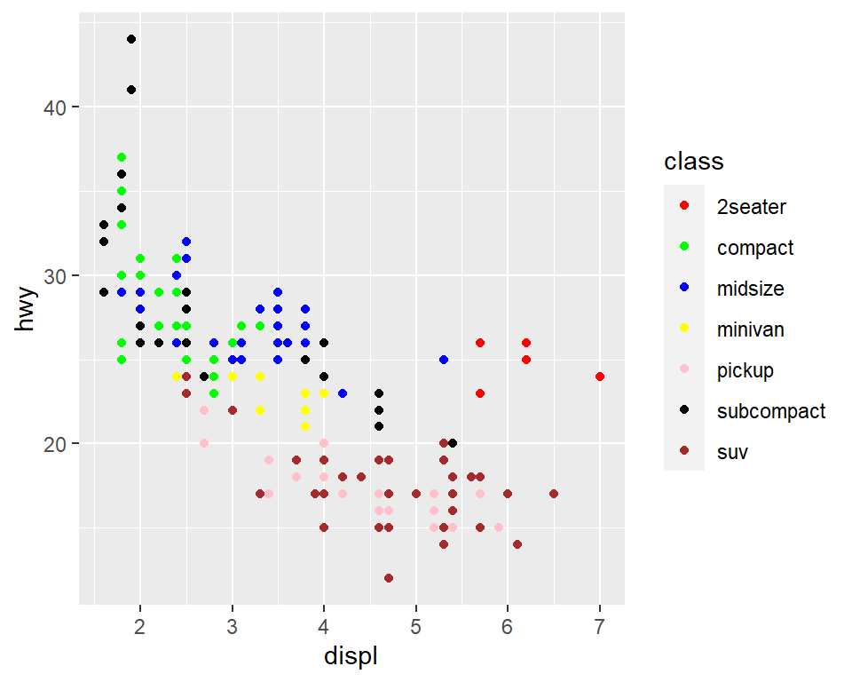

```r
pc +
  geom_point() +
  scale_color_manual(values = c("red", "green", "blue", "yellow", "pink", "black", "brown"))
```

##### 2.1.1.1.1 凡例の名前変更

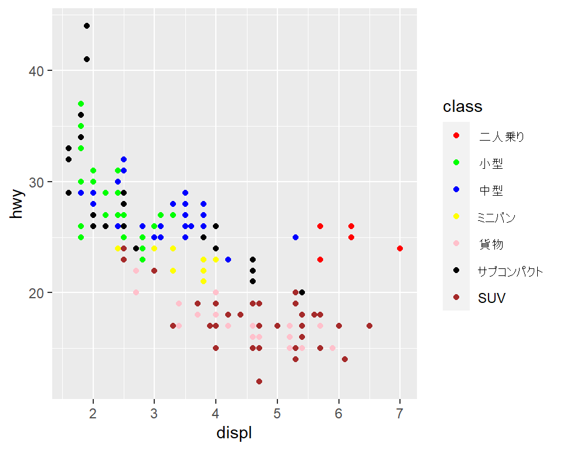

```r
pc +
  geom_point() +
  scale_color_manual(values = c("red", "green", "blue", "yellow", "pink", "black", "brown"),
                     labels = c("二人乗り","小型","中型","ミニバン","貨物","サブコンパクト","SUV"))
```

#### 2.1.1.2 用意された色のセットを使用

- 詳しくは`?scale_color_brewer`
- ユニバーサルカラーのセット例
  - Set2 （8色まで）
  - Paired（12色まで）
  - Dark2 （8色まで）

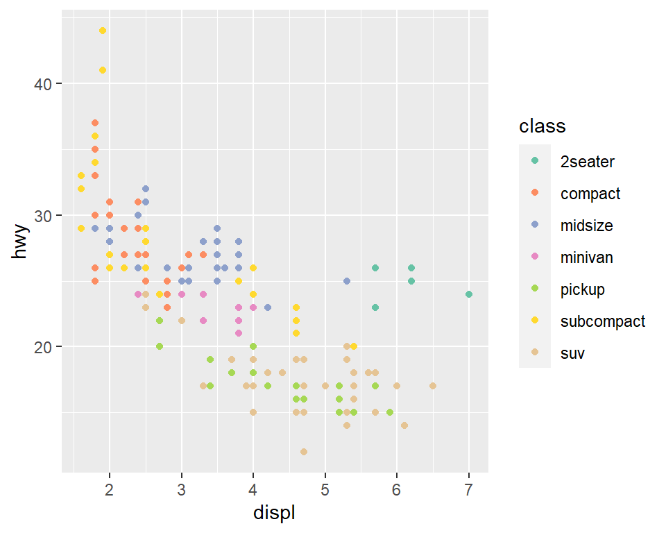

```r
pc +
  geom_point() +
  scale_color_brewer(palette = "Set2")
```

### 2.1.2 形

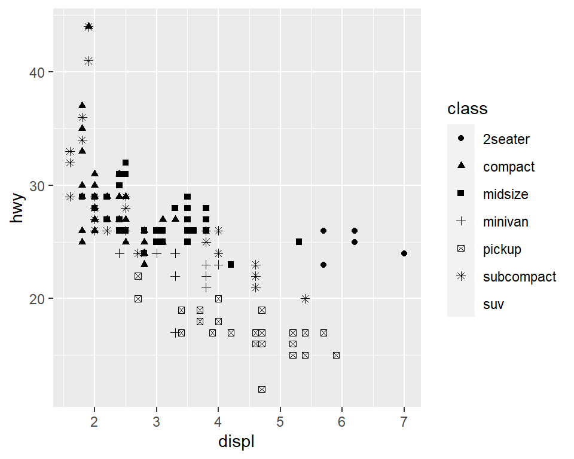

```r
ggplot(mpg, aes(displ, hwy,
                shape = class)) +
  geom_point()
```

### 2.1.3 テキスト

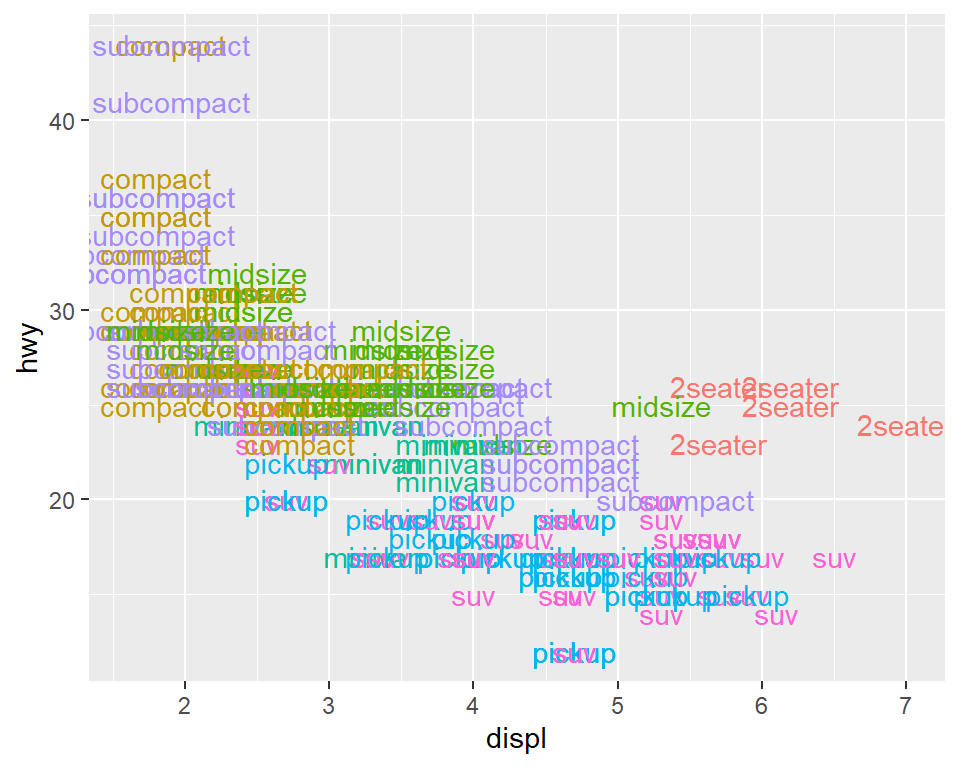

```r
pc +
  geom_text(aes(label = class), show.legend = FALSE) # 凡例なし
```

#### 2.1.3.1 重なりをなくす

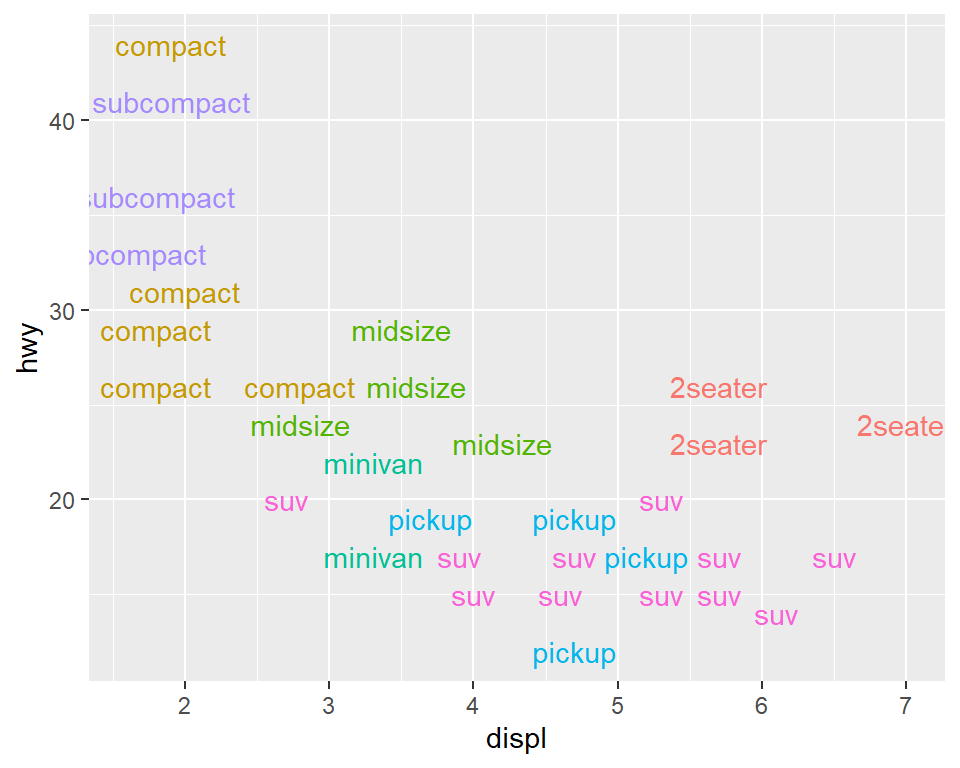

```r
pc +
  geom_text(aes(label = class), show.legend = FALSE,
            check_overlap = TRUE ) # 凡例なし
```

#### 2.1.3.2 斜めにする

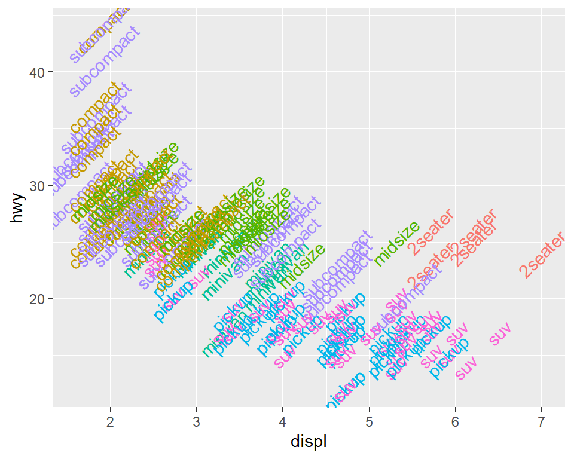

```r
pc +
  geom_text(aes(label = class), show.legend = FALSE,
            angle = 45 ) # 凡例なし
```

### 2.1.4 画像

- ggimageパッケージを使用
- 区分するカテゴリをcase_whenで画像の保存先に割り当てる

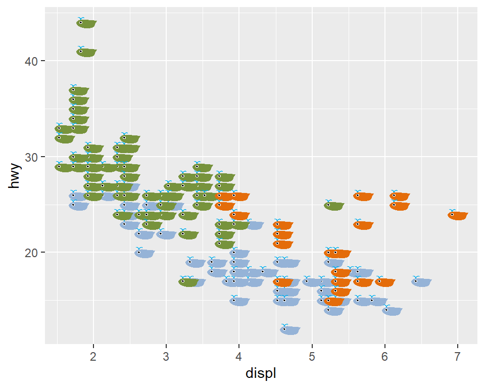

```r
mpg %>%
    mutate(drv_image =
           case_when(drv == "4" ~ "image/kujira.PNG",
                     drv == "f" ~ "image/kujira_green.PNG",
                     drv == "r" ~ "image/kujira_orange.PNG")) %>%

ggplot(aes(displ, hwy)) +
  geom_image(aes(image = drv_image), size = .05)
```

## 2.2 凡例の調整

### 2.2.1 凡例の位置

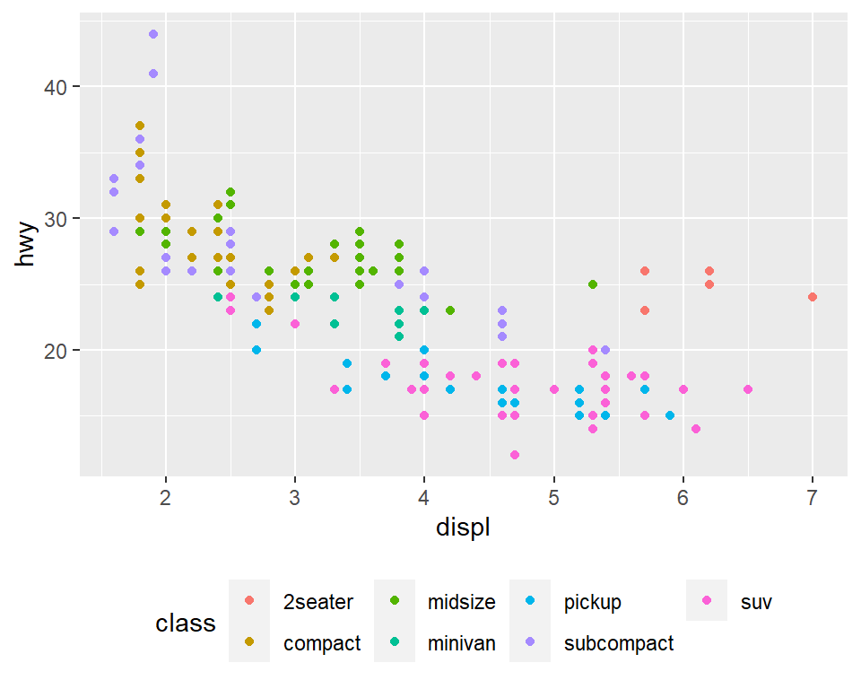

```r
pc +
 geom_point() +
 theme(legend.position = "bottom")
```

### 2.2.2 凡例を消す

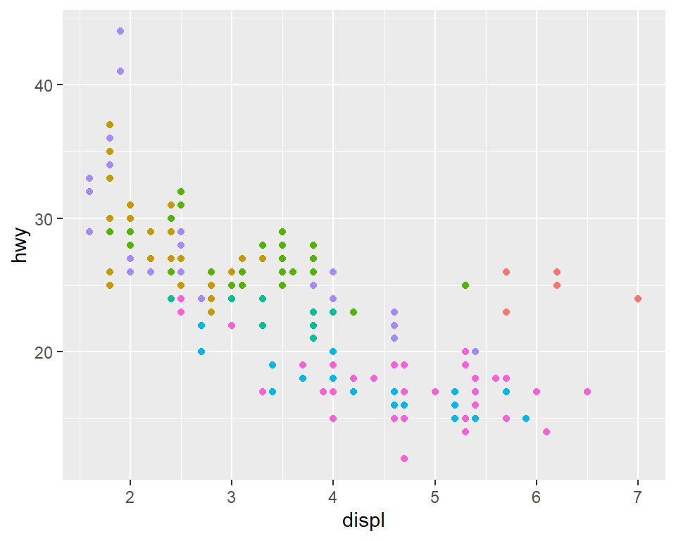

```r
pc +
 geom_point() +
 theme(legend.position = "none")
```

### 2.2.3 凡例をグラフ中に

- `legend.position =` で、x軸、y軸のそれぞれを0-1の範囲で表した相対的な位置の座標で表す
- `legend.direction = "horizontal"`で、凡例を横向きに展開

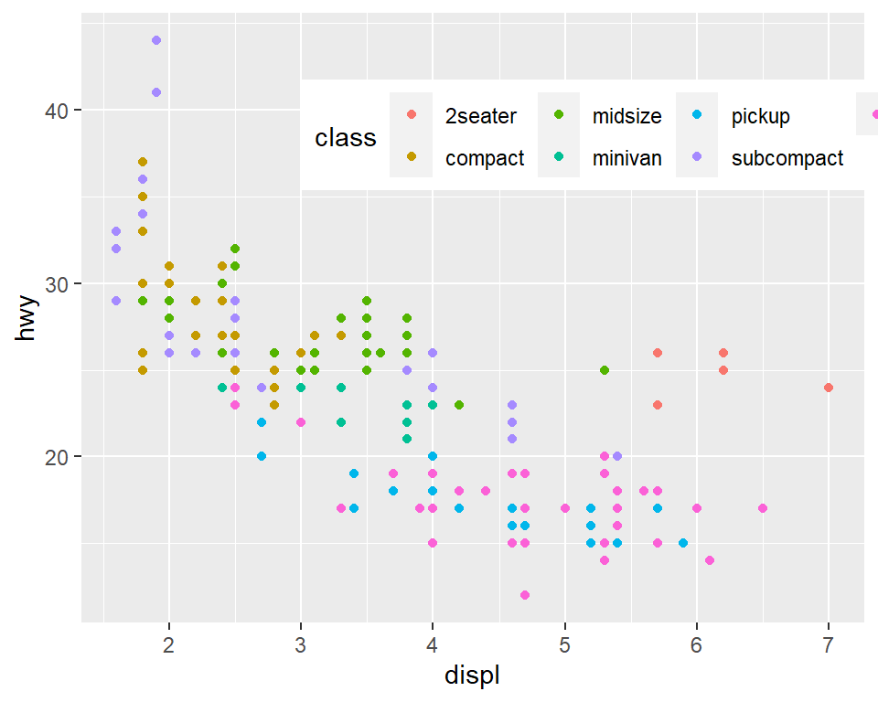

```r
pc +
 geom_point() +
 theme(legend.position = c(.70, .80),
       legend.direction = "horizontal")
```

#### 2.2.3.1 凡例のボックスの背景色を透明に

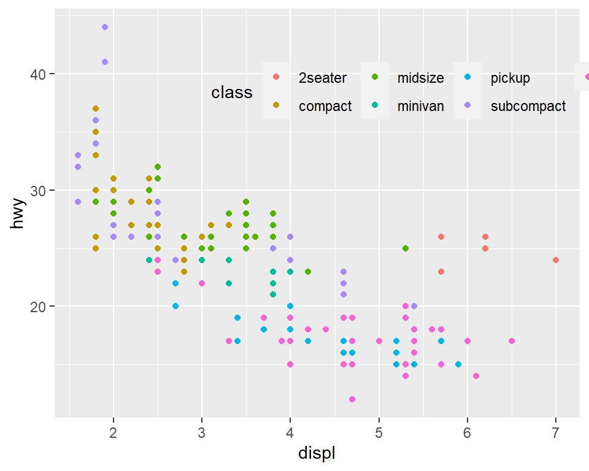

```r
pc +
 geom_point() +
 theme(legend.position = c(.70, .80),
       legend.direction = "horizontal",
       legend.background = element_blank())
```

### 2.2.4 凡例の行数や列数指定

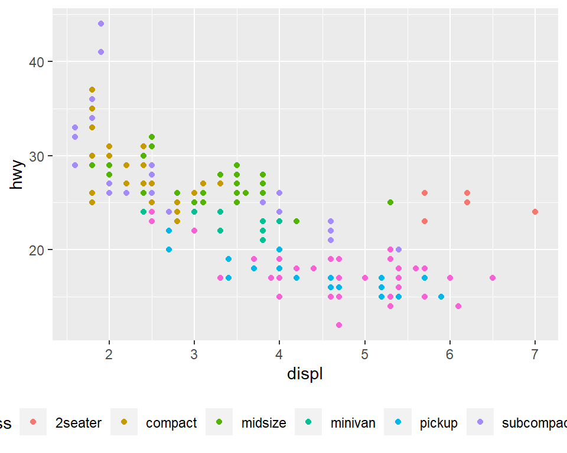

```r
pc +
 geom_point() +
 theme(legend.position = "bottom") +
 guides(color = guide_legend(nrow = 1))
```

### 2.2.5 凡例のタイトル名変更

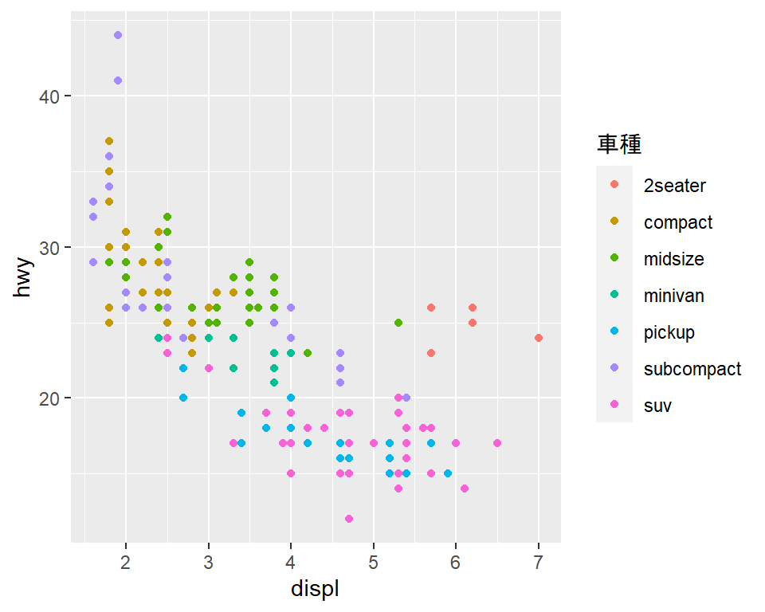

```r
pc +
 geom_point() +
 guides(color = guide_legend(title = "車種"))
```

```r
# こちらでもOK
# pc +
#  geom_point() +
#   labs(color = "車種")
```

#### 2.2.5.1 タイトルを消す

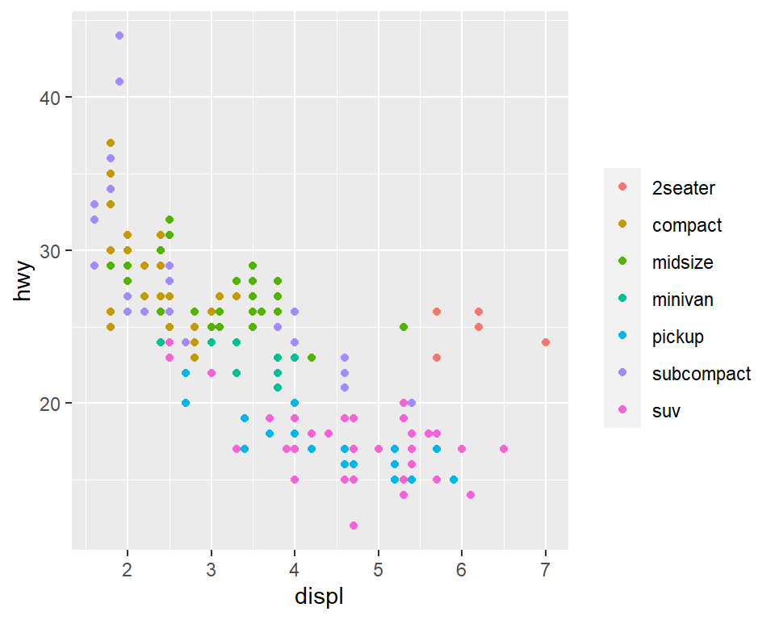

```r
pc +
 geom_point() +
 guides(color = guide_legend(title = ""))
```

```r
# こちらでもOK
# pc +
#  geom_point() +
#   labs(color = "")
```

#### 2.2.5.2 長いタイトル名の改行

- 改行部分に`\n`を入れる

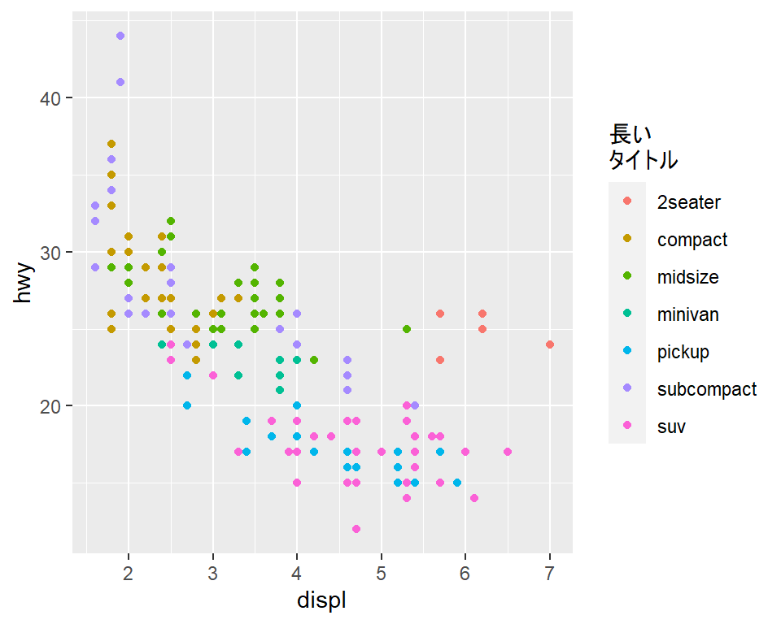

```r
pc +
 geom_point() +
 guides(color = guide_legend(title = "長い\nタイトル"))
```